# Higher Education Outcomes of Youth involved with Foster Care

Published: April 2024

##### Return to Reports Page

In the complex landscape of educational and professional journeys, youth involved in foster care navigate unique challenges that often influence their postsecondary and workforce outcomes. This data report seeks to unravel and illuminate these paths by examining five critical questions for a cohort of 3,562 individuals. The cohort is limited to Rhode Island youth who were in foster care in 2000 or later and were born from 1993 through 1997.

The exploration begins with a look at the demographics of the cohort; the distribution of race, sex, and years of birth. This is followed by a review of the cohort’s enrollment patterns at postsecondary institutions, discerning choices made between public and private options, both in- and out-of-state. The analysis continues to examine postsecondary data, focusing on persistence rates in an attempt to shed light on the successes and challenges faced by youth involved in foster care in their academic pursuits. Further postsecondary exploration focuses on the attainment of certificates or degrees, providing an understanding of the cohort’s educational achievements. Moving beyond educational outcomes, the analysis reviews the employment landscape both for those who did not enroll in higher education, and for those who earned certificates or degrees, examining the industries of employment and median wages of both groups.

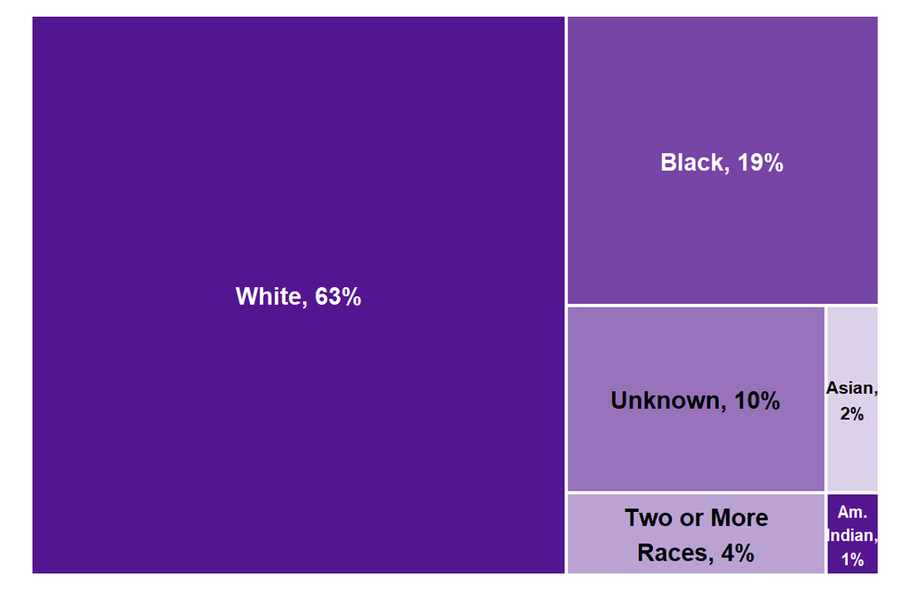

**Figure 1:** Cohort demographics by race

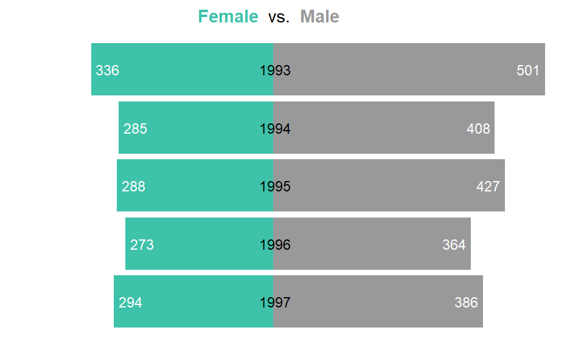

**Figure 2:** Cohort demographics by sex

#### Postsecondary Enrollment:

In this section, we explore the postsecondary enrollment patterns among students involved in foster care, differentiating between Rhode Island (RI) and out-of-state institutions, as well as public and private institutions. Figure 3 depicts the distribution of students across these categories, shedding light on the choices they make when pursuing higher education. This information is crucial for understanding the educational trajectories of this demographic.

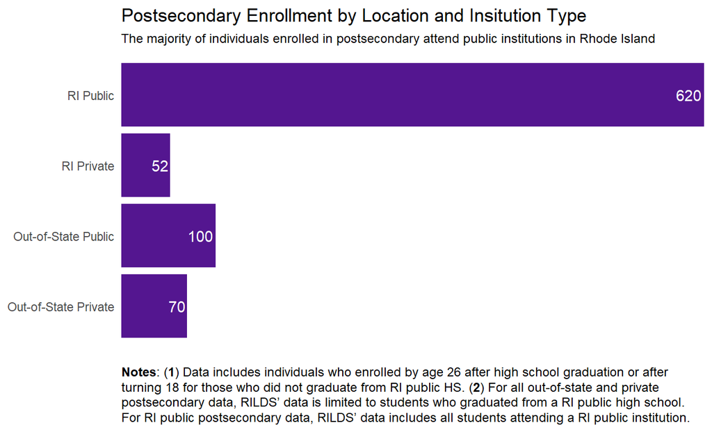

**Figure 3:** Postesecondary enrollment outcomes of youth involved in foster care

#### Postsecondary Persistence:

Examining persistence rates is crucial for evaluating the success of youth involved in foster care in their academic journeys. By comparing these rates across RI public, RI private, and out-of-state institutions, we gain insights into the challenges and successes these individuals experience.

For this analysis, students are considered to have persisted if they attended **any** institution one semester (or one year) after their first postsecondary enrollment. The percentages below represent the number of students persisting out of the number that enrolled in postsecondary institutions after the students’ high school graduation or after the student turned 18 for those who did not graduate high school. Again, this cohort is limited to students who were born from 1993 through 1997, in foster care sometime in 2000 or later, and enrolled in postsecondary before age 26. Roughly one out of two of the 830 students who enrolled in higher education prior to 2022 persisted into their second semester. The denominators of the persistence calculations shown in Figure 4 were limited to those who enrolled prior to 2022 based on the available years of data in RILDS’ current postsecondary data holdings.

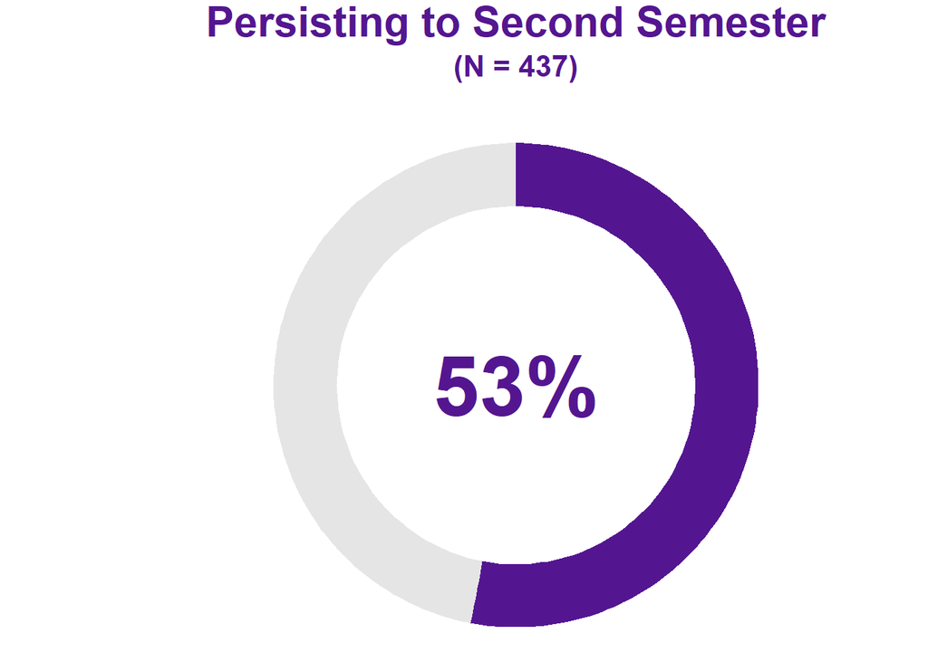

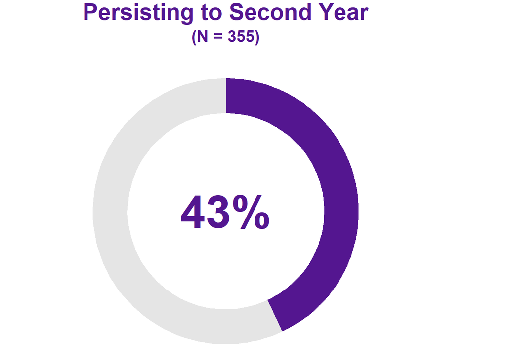

**Figure 4:** Postesecondary persistence rates of youth involved in foster care

#### Attainment of Certificates or Degrees:

This section delves into the educational achievements of students involved in foster care, focusing on the number who earned certificates or degrees. The visualizations highlight the distribution of these achievements across RI public, RI private, and out-of-state institutions. According to a recent study by the Lumina Foundation and Gallup[^1], a postsecondary degree is positively correlated with higher earnings, better health, and greater civic engagement. Understanding the educational outcomes of this particularly vulnerable population is essential for policymakers and practitioners as they implement strategies to facilitate academic success for youth involved with foster care.

Given the age range of the students included in this cohort, not all of the 3,562 individuals would reasonably be expected to graduate within the time frame of RILDS’ postsecondary data. Only 169 individuals appear in RILDS’ data as receiving a degree or certificate before turning 26, and these individuals are represented in Figures 5 and 6. Attainment rate was calculated based on A) all individuals who enrolled in postsecondary (N = 796), and B) only those individuals who persisted to a second year (N = 338). Individuals who would not reasonably be expected to have graduated based on their first enrollment date and enrollment type (i.e. 2-year or 4-year) are excluded from the denominators used to calculate the attainment rates shown in Figure 5 (Attainment A and Attainment B).

Roughly one out of two individuals who completed postsecondary education did so at one of the three public Rhode Island higher education institutions, as shown in Figure 6.

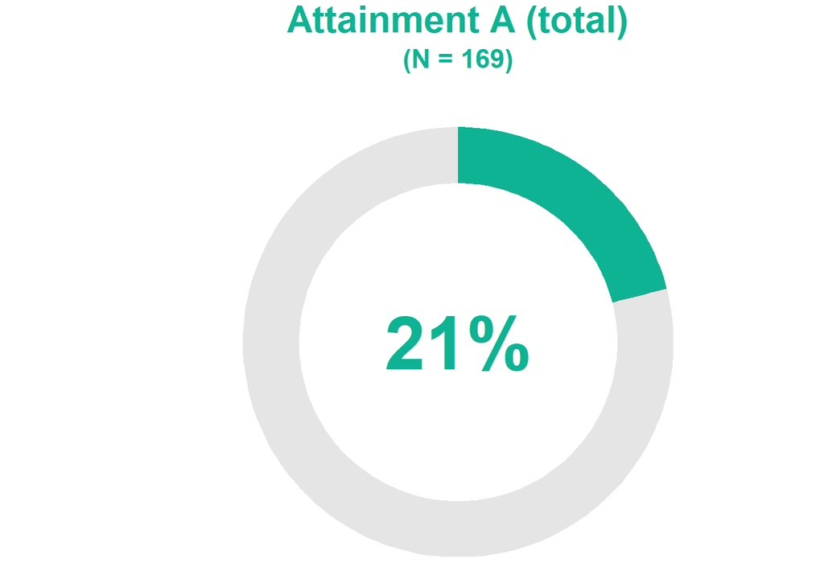

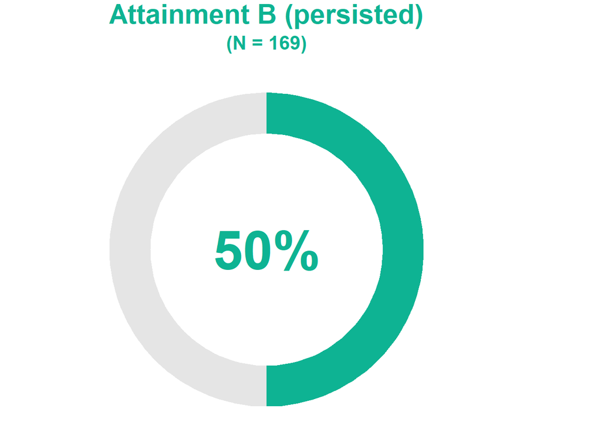

**Figure 5:** Postesecondary attainment rates of youth involved in foster care

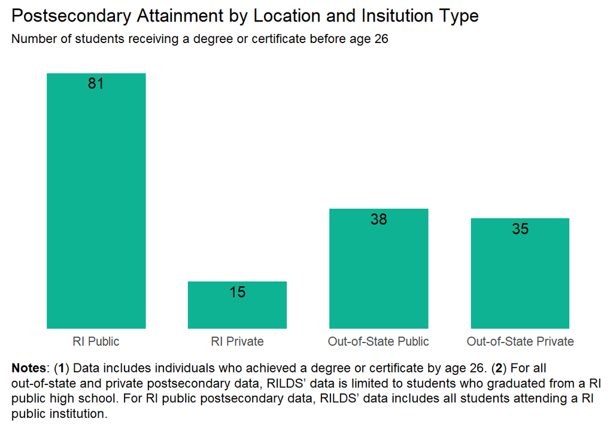

**Figure 6:** Postesecondary attainment outcomes of youth involved in foster care

#### Employment Outcomes for Individuals not Enrolled in Postsecondary:

For youth in foster care who did not pursue postsecondary education (“non-enrolled”), exploring their employment outcomes is crucial. This section examines the industries in which they are employed the longest and provides insights into their median wages. The visualizations bring attention to the diverse career paths taken by non-enrolled individuals, offering a comprehensive view of their workforce integration. For those who did not enroll in postsecondary, 1,392 individuals were identified in RILDS’ wage records. The three most common industries of employment for this group were *Accommodation and Food Services*, *Retail Trade*, and *Administrative and Support and Waste Management and Remediation Services*. These three industries account for about 76% of the jobs held by those not enrolled in postsecondary.

As shown in Figure 7, this population’s inflation adjusted median annual wages do not reach Rhode Island’s minimum wage by the time individuals turn 26 years old.

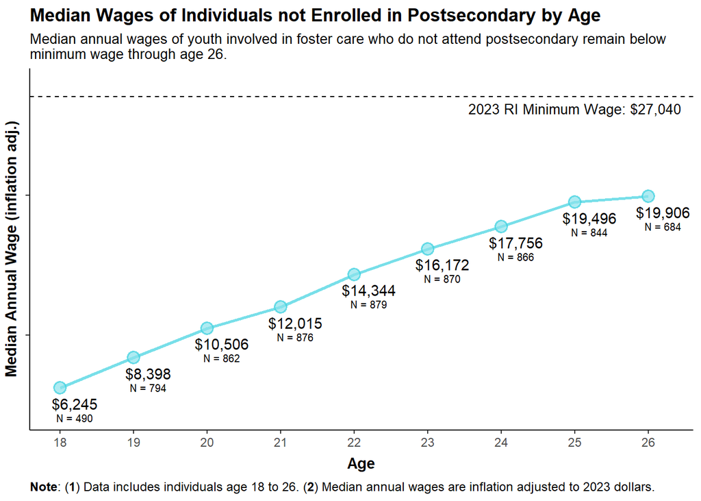

**Figure 7:** Workforce outcomes of non-enrolled youth involved in foster care

#### Employment Outcomes for Certificate or Degree Holders:

The final section focuses on the youth involved in foster care who have successfully earned certificates or degrees prior to September of 2017 (N = 48). It explores the industries in which they were most recently employed and provides information on median wages. This data is instrumental in understanding the professional trajectories of individuals following degree or certificate attainment from a postsecondary institution, facilitating targeted support and interventions to ensure sustained success. For those who graduated from a postsecondary program, the most common industry of employment is *Retail Trade* (N = 11). This industry accounts for about 23% of the jobs held by those who graduated from postsecondary. Fewer than 10 individuals were employed in all other industries.

As shown in Figure 8, this population’s inflation adjusted median annual wages exceed Rhode Island’s minimum wage one year following graduation and exceed Rhode Island’s Living Wage[^2] four years following graduation. The data in Figure 8 includes youth involved in foster care who graduated from postsecondary by age 26 prior to September 2017. Wage data for these individuals were followed for five years following graduation regardless of age (e.g. for a student who graduated at the age of 24 in 2016, the wage analysis followed this student to the age of 29 in 2021).

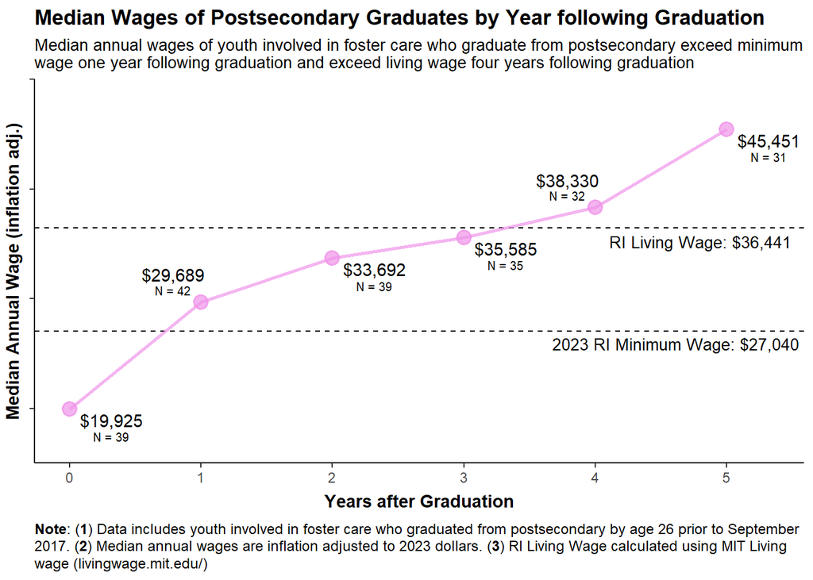

**Figure 8:** Workforce outcomes of youth involved in foster care who graduate from postsecondary

#### Ensuring Success:

This exploration of postsecondary and workforce outcomes among Rhode Island individuals involved in foster care unveils a multifaceted narrative. The visualizations and analyses presented in each section provide valuable insights into enrollment patterns, academic persistence, educational achievements, and workforce integration. By understanding these trajectories, specifically how workforce outcomes differ between those who engage in postsecondary and those who do not, decision makers are better equipped to identify areas for support and intervention, enabling an environment that nurtures the aspirations of youth involved in foster care.

This report analyzed a cohort of 3,562 individuals, limited to Rhode Island youth who were in foster care in 2000 or later and were born from 1993 through 1997.

- 24% appeared in RILDS’ postsecondary data by age 26.
- Three quarters of these postsecondary students attended Rhode Island public higher education institutions.
- 53% of individuals enrolled in postsecondary persisted to a second semester, while only 43% persisted to a second year.
- 50% of those who persisted to a second year graduated with a degree or certificate (21% of all enrolled students)
- For those that do not attend postsecondary, their inflation adjusted median annual wages do not reach Rhode Island’s minimum wage by the time individuals turn 26 years old
- For those who graduate from postsecondary, their inflation adjusted median annual wages exceed Rhode Island’s minimum wage one year following graduation and exceed Rhode Island’s Living Wage four years following graduation.

Based on these results, stakeholders are encouraged to collaborate and implement strategies that pave the way for success in both academic and professional realms for youth involved in foster care.

#### About this Report:

This report was developed by the Rhode Island Longitudinal Data System (RILDS) Center. The report is based on data stored in RILDS as of April 2024.

Additional information regarding the data sets used in this report:

- Department of Children, Youth & Families (DCYF) - Adoption and Foster Care Reporting System (AFCARS) Data
  - Records covering reporting years 2000 through 2022.
- National Student Clearinghouse (NSC) data via the Rhode Island Department of Education (RIDE) - Postsecondary Enrollment and Completions Data
  - Records covering terms Spring 2010 through Fall 2023.
  - Data set limitation: Only students who graduated from a Rhode Island public high school are included in this data.
- Office of the Postsecondary Commissioner (OPC) – Postsecondary Enrollment and Completions Data
  - Records covering terms Spring 2007 through Fall 2023.
  - Data set limitation: Only students who attend one of the three RI public institutions are included in this data.
- Department of Labor and Training (DLT) – Employment & Wage Data
  - Records covering quarters Q1 2011 through Q4 2022.
  - Data set limitation: Only employees of employers that pay into RI unemployment insurance are included in this data.

All aggregated values below ten (10) were suppressed for this report.

[figure not shown]

[^1]: https://www.gallup.com/analytics/468986/state-of-higher-education.aspx
[^2]: https://livingwage.mit.edu/